# Flight Delays Prediction / Analytics

### Plot continous variables as well

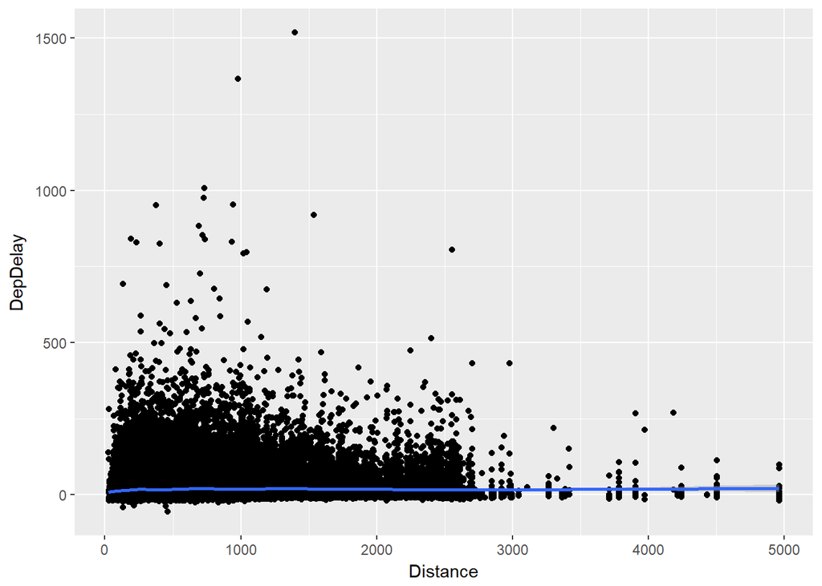

```r
ggplot(tripsplaneairports, aes(Distance, DepDelay)) + geom_point() + geom_smooth() + scale_size_area(max_size = 2)
```

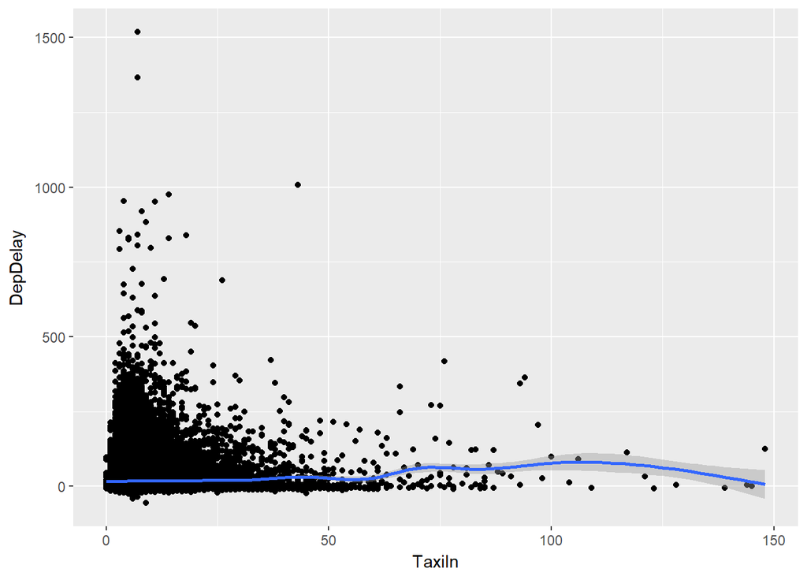

```r
ggplot(tripsplaneairports, aes(TaxiIn, DepDelay)) + geom_point() + geom_smooth() + scale_size_area(max_size = 2)
```

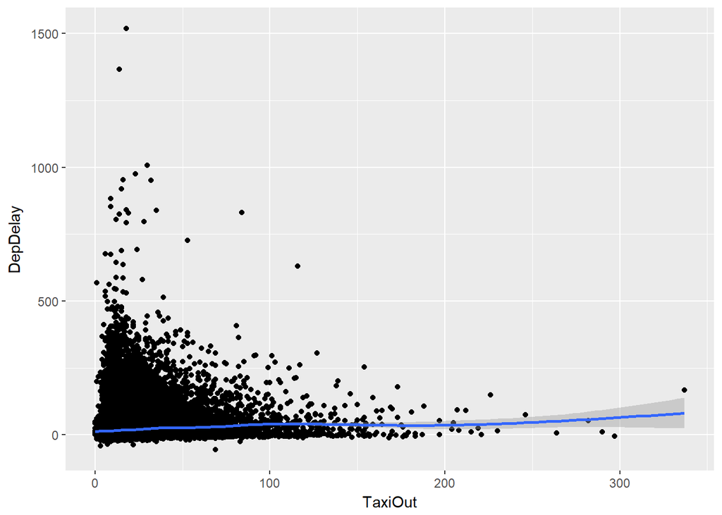

```r
ggplot(tripsplaneairports, aes(TaxiOut, DepDelay)) + geom_point() + geom_smooth() + scale_size_area(max_size = 2)
```

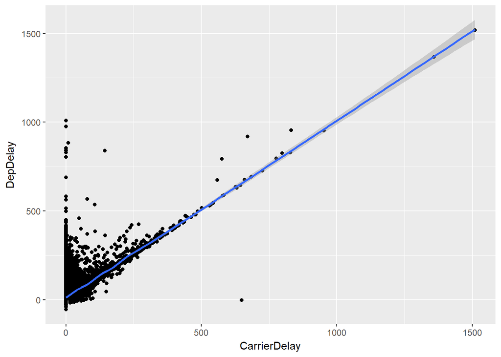

```r
ggplot(tripsplaneairports, aes(CarrierDelay,DepDelay)) + geom_point() + geom_smooth() + scale_size_area(max_size = 2)
```

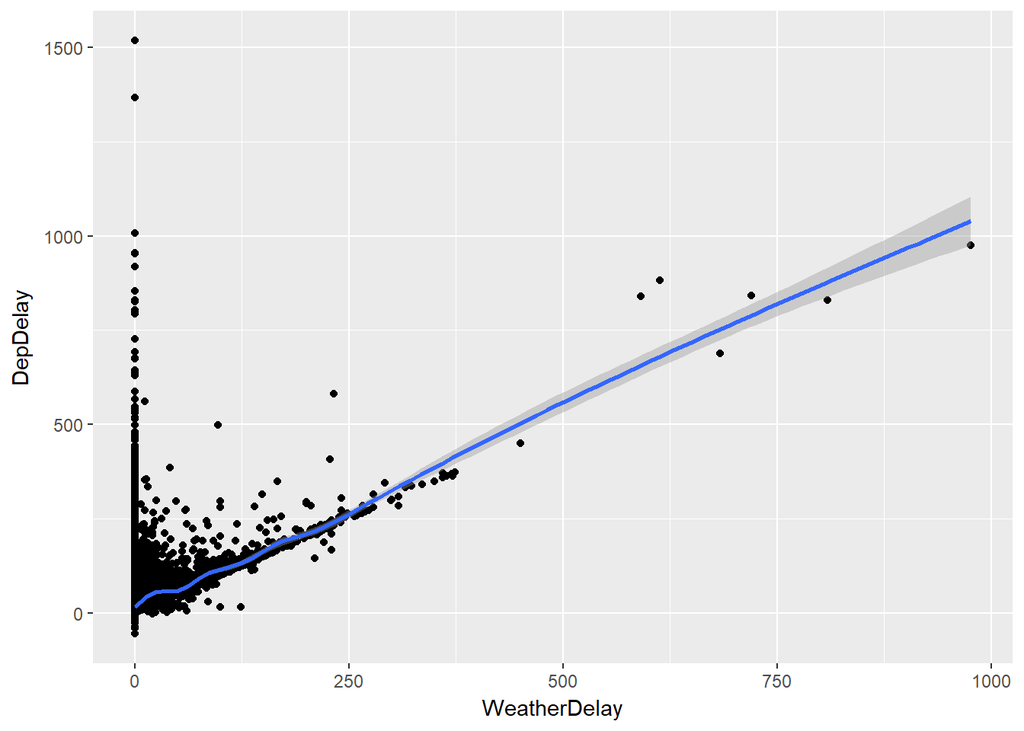

```r
ggplot(tripsplaneairports, aes(WeatherDelay, DepDelay)) + geom_point() + geom_smooth() + scale_size_area(max_size = 2)
```

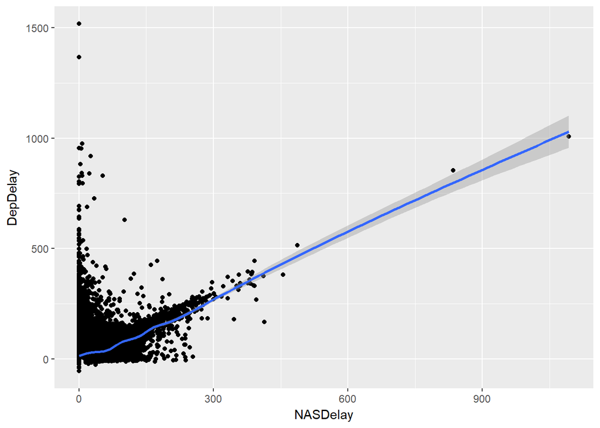

```r
ggplot(tripsplaneairports, aes(NASDelay, DepDelay)) + geom_point() + geom_smooth() + scale_size_area(max_size = 2)
```

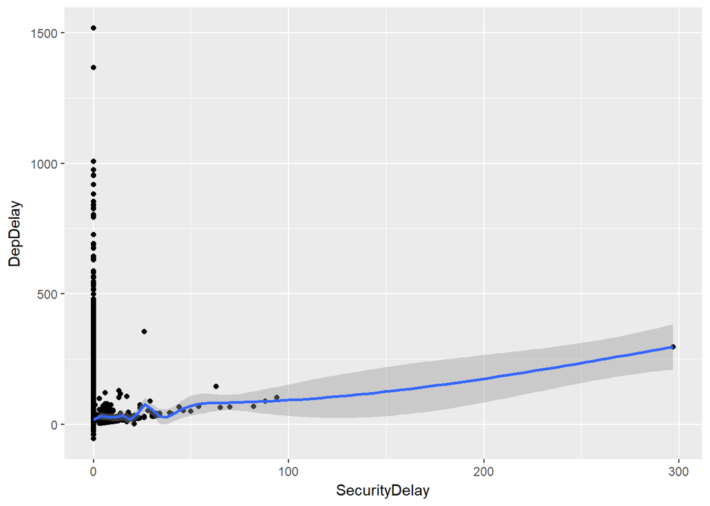

```r
ggplot(tripsplaneairports, aes(SecurityDelay, DepDelay)) + geom_point() + geom_smooth() + scale_size_area(max_size = 2)
```

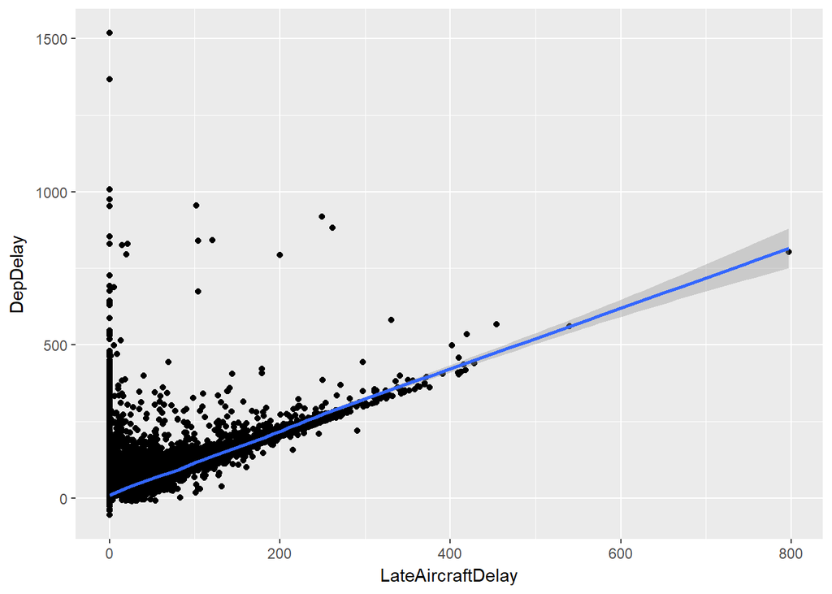

```r
ggplot(tripsplaneairports, aes(LateAircraftDelay, DepDelay)) + geom_point() + geom_smooth() + scale_size_area(max_size = 2)
```

Now based on exploratory data analysis, we need to choose the variables that are potentially significant and then start the modeling. Based on this plot, we can see ArrDelay has positive co-relation with DepDelay, TaxiOut, CarrierDelay, NASDelay, WeatherDelay, LateAirCraftDelay And DepDelay has positive co-relation wth TaxiOut, CarrierDelay, NASDelay, WeatherDelay, LateAirCraftDelay So, from continous variable point of view, we got the starting point. We can also see that the significant variables are not co-related to each other. i.e there is no multico-linearity.

#### If the multi-colinirity is present, then we should have addressed. i.e combining variables or picking only most significant one and leaving other. PCA is one of the method to address the same. We don’t need here.

Now we have fair idea, now let us see variable significane and based on the results we can choose the best variable combination. We can also statistically, prove what we saw visually befor choosing the final machine learning model.

```r
modeltrips <- na.omit(tripsplaneairports[,c("Dest","Origin", "Month", "DayOfWeek",  "ArrTime", "UniqueCarrier", "ActualElapsedTime", "CRSElapsedTime",
                                    "TaxiOut", "Diverted",  "CarrierDelay", "WeatherDelay",    "NASDelay",        "SecurityDelay",   "LateAircraftDelay" ,"ArrHour",
                                    "DepHour",         "ArrTimeofday",    "DepTimeofday",       "WeekOfMonth",    "Origincity",
                                    "Originstate",   "Destcity", "Deststate" ,  "ArrDelay", "DepDelay" )])
```

#### See each variable, how significant to the DepDelay and ArrDelay

```r
lm.fit1 <- stats::lm(formula = DepDelay ~ factor(Month), data = modeltrips)
summary(lm.fit1)
```

```
##
## Call:
## stats::lm(formula = DepDelay ~ factor(Month), data = modeltrips)
##
## Residuals:
##     Min      1Q  Median      3Q     Max
##  -80.25  -22.02  -14.65    3.77 1495.58
##
## Coefficients:
##                 Estimate Std. Error t value Pr(>|t|)
## (Intercept)      18.1213     0.4909  36.911  < 2e-16 ***
## factor(Month)2    3.9419     0.7091   5.559 2.73e-08 ***
## factor(Month)3    2.1114     0.6835   3.089  0.00201 **
## factor(Month)4   -1.6241     0.6996  -2.321  0.02027 *
## factor(Month)5   -4.1054     0.6948  -5.908 3.47e-09 ***
## factor(Month)6    6.6458     0.6862   9.685  < 2e-16 ***
## factor(Month)7    4.2985     0.6894   6.235 4.54e-10 ***
## factor(Month)8    2.2593     0.6914   3.268  0.00108 **
## factor(Month)9   -7.9945     0.7185 -11.127  < 2e-16 ***
## factor(Month)10  -7.0122     0.7071  -9.916  < 2e-16 ***
## factor(Month)11  -5.4705     0.7101  -7.704 1.33e-14 ***
## factor(Month)12   7.1292     0.6901  10.331  < 2e-16 ***
## ---
## Signif. codes:  0 '***' 0.001 '**' 0.01 '*' 0.05 '.' 0.1 ' ' 1
##
## Residual standard error: 44.16 on 95411 degrees of freedom
## Multiple R-squared:  0.01244,    Adjusted R-squared:  0.01232
## F-statistic: 109.2 on 11 and 95411 DF,  p-value: < 2.2e-16
```

```r
summary(lm.fit1)$r.squared
```

```
## [1] 0.01243512
```

```r
summary(lm.fit1)$adj.r.squared
```

```
## [1] 0.01232127
```

```r
summary(lm.fit1)$coeff
```

```
##                  Estimate Std. Error    t value      Pr(>|t|)
## (Intercept)     18.121261  0.4909475  36.910792 3.864112e-296
## factor(Month)2   3.941852  0.7091334   5.558689  2.725335e-08
## factor(Month)3   2.111400  0.6835106   3.089052  2.008539e-03
## factor(Month)4  -1.624064  0.6996365  -2.321297  2.027292e-02
## factor(Month)5  -4.105390  0.6948425  -5.908375  3.466662e-09
## factor(Month)6   6.645830  0.6861963   9.685027  3.574263e-22
## factor(Month)7   4.298489  0.6894079   6.235045  4.535300e-10
## factor(Month)8   2.259269  0.6913873   3.267733  1.084508e-03
## factor(Month)9  -7.994550  0.7184504 -11.127490  9.603271e-29
## factor(Month)10 -7.012201  0.7071442  -9.916226  3.631445e-23
## factor(Month)11 -5.470519  0.7100547  -7.704362  1.327583e-14
## factor(Month)12  7.129161  0.6901043  10.330556  5.284346e-25
```

```r
anova(lm.fit1)
```

```
## Analysis of Variance Table
##
## Response: DepDelay
##                  Df    Sum Sq Mean Sq F value    Pr(>F)
## factor(Month)    11   2342619  212965  109.22 < 2.2e-16 ***
## Residuals     95411 186044600    1950
## ---
## Signif. codes:  0 '***' 0.001 '**' 0.01 '*' 0.05 '.' 0.1 ' ' 1
```

Month seems to be significant as evident in EDA.

```r
lm.fit2 <-  stats::lm(formula = DepDelay ~ factor(DepHour) , data = modeltrips)
summary(lm.fit2)
```

[output not shown]

Dep hour seems to be more significant

```r
lm.fit3 <-  stats::lm(formula = DepDelay ~ factor(DepTimeofday) , data = modeltrips)
summary(lm.fit3)
```

[output not shown]

This seems to be significant

```r
lm.fit4 <-  stats::lm(formula = DepDelay ~ factor(Month) +  factor(DepTimeofday) + factor(DepHour), data = modeltrips)
summary(lm.fit4)
```

```
##
## Call:
## stats::lm(formula = DepDelay ~ factor(Month) + factor(DepTimeofday) +
##     factor(DepHour), data = modeltrips)
##
## Residuals:
##     Min      1Q  Median      3Q     Max
##  -98.27  -21.28  -11.77    2.77 1506.76
##
## Coefficients: (3 not defined because of singularities)
##                       Estimate Std. Error t value Pr(>|t|)
## (Intercept)            11.3547     3.8447   2.953 0.003144 **
## factor(Month)2          3.9114     0.6987   5.598 2.18e-08 ***
## factor(Month)3          2.1100     0.6735   3.133 0.001731 **
## factor(Month)4         -1.6740     0.6894  -2.428 0.015174 *
## factor(Month)5         -3.9698     0.6846  -5.799 6.71e-09 ***
## factor(Month)6          6.4511     0.6762   9.540  < 2e-16 ***
## factor(Month)7          4.3570     0.6793   6.414 1.43e-10 ***
## factor(Month)8          2.2574     0.6813   3.314 0.000921 ***
## factor(Month)9         -7.7612     0.7079 -10.963  < 2e-16 ***
## factor(Month)10        -6.7587     0.6967  -9.701  < 2e-16 ***
## factor(Month)11        -5.1976     0.6997  -7.429 1.11e-13 ***
## factor(Month)12         7.3024     0.6800  10.739  < 2e-16 ***
## factor(DepTimeofday)1   2.6276     3.8548   0.682 0.495476
## factor(DepTimeofday)2  15.2597     3.8526   3.961 7.47e-05 ***
## factor(DepTimeofday)3   9.2761     4.2646   2.175 0.029621 *
## factor(DepHour)1       -6.4877     7.5883  -0.855 0.392574
## factor(DepHour)2       -7.6476    14.9960  -0.510 0.610073
## factor(DepHour)3       86.4641    30.9996   2.789 0.005285 **
## factor(DepHour)4        3.8819    11.5270   0.337 0.736297
## factor(DepHour)5       -4.0391     4.2279  -0.955 0.339406
## factor(DepHour)6       -8.6869     0.7816 -11.114  < 2e-16 ***
## factor(DepHour)7       -7.1004     0.7782  -9.124  < 2e-16 ***
## factor(DepHour)8       -5.0095     0.7766  -6.450 1.12e-10 ***
## factor(DepHour)9       -3.1539     0.7867  -4.009 6.09e-05 ***
## factor(DepHour)10      -0.9227     0.7897  -1.168 0.242623
## factor(DepHour)11           NA         NA      NA       NA
## factor(DepHour)12     -10.5281     0.7779 -13.533  < 2e-16 ***
## factor(DepHour)13      -8.6034     0.7638 -11.264  < 2e-16 ***
## factor(DepHour)14      -5.5395     0.7680  -7.213 5.53e-13 ***
## factor(DepHour)15      -4.0866     0.7782  -5.251 1.51e-07 ***
## factor(DepHour)16      -1.8222     0.7610  -2.395 0.016644 *
## factor(DepHour)17           NA         NA      NA       NA
## factor(DepHour)18       6.8364     1.9871   3.440 0.000581 ***
## factor(DepHour)19       6.6993     1.9890   3.368 0.000757 ***
## factor(DepHour)20       7.4852     2.0229   3.700 0.000216 ***
## factor(DepHour)21       4.5590     2.0443   2.230 0.025745 *
## factor(DepHour)22      -2.3687     2.2840  -1.037 0.299704
## factor(DepHour)23           NA         NA      NA       NA
## ---
## Signif. codes:  0 '***' 0.001 '**' 0.01 '*' 0.05 '.' 0.1 ' ' 1
##
## Residual standard error: 43.5 on 95388 degrees of freedom
## Multiple R-squared:  0.04168,    Adjusted R-squared:  0.04134
## F-statistic:   122 on 34 and 95388 DF,  p-value: < 2.2e-16
```

This combination seems to be significatnt, Adj R Squared is increasing…

```r
lm.fit5 <-  stats::lm(formula = DepDelay ~ factor(Month) +  factor(DepTimeofday) + factor(DepHour)+ factor(DayOfWeek) + factor(WeekOfMonth), data = modeltrips)
summary(lm.fit5)
```

```
##
## Call:
## stats::lm(formula = DepDelay ~ factor(Month) + factor(DepTimeofday) +
##     factor(DepHour) + factor(DayOfWeek) + factor(WeekOfMonth),
##     data = modeltrips)
##
## Residuals:
##     Min      1Q  Median      3Q     Max
##  -97.27  -21.28  -11.65    2.86 1506.61
##
## Coefficients: (3 not defined because of singularities)
##                         Estimate Std. Error t value Pr(>|t|)
## (Intercept)            10.662774   3.866556   2.758 0.005822 **
## factor(Month)2          3.677721   0.699730   5.256 1.48e-07 ***
## factor(Month)3          1.986061   0.673569   2.949 0.003193 **
## factor(Month)4         -1.817167   0.689420  -2.636 0.008395 **
## factor(Month)5         -4.026123   0.684256  -5.884 4.02e-09 ***
## factor(Month)6          6.311673   0.676420   9.331  < 2e-16 ***
## factor(Month)7          4.291123   0.679235   6.318 2.67e-10 ***
## factor(Month)8          2.141349   0.681156   3.144 0.001669 **
## factor(Month)9         -7.840518   0.707975 -11.075  < 2e-16 ***
## factor(Month)10        -6.845569   0.696268  -9.832  < 2e-16 ***
## factor(Month)11        -5.421900   0.699723  -7.749 9.38e-15 ***
## factor(Month)12         7.210203   0.680021  10.603  < 2e-16 ***
## factor(DepTimeofday)1   2.547360   3.851493   0.661 0.508360
## factor(DepTimeofday)2  15.143743   3.849349   3.934 8.36e-05 ***
## factor(DepTimeofday)3   9.068693   4.260994   2.128 0.033314 *
## factor(DepHour)1       -6.850929   7.581706  -0.904 0.366203
## factor(DepHour)2       -7.538857  14.983067  -0.503 0.614854
## factor(DepHour)3       89.009340  30.973912   2.874 0.004058 **
## factor(DepHour)4        4.958356  11.517394   0.431 0.666825
## factor(DepHour)5       -4.210685   4.224247  -0.997 0.318869
## factor(DepHour)6       -8.648163   0.781024 -11.073  < 2e-16 ***
## factor(DepHour)7       -7.112068   0.777533  -9.147  < 2e-16 ***
## factor(DepHour)8       -4.982651   0.775990  -6.421 1.36e-10 ***
## factor(DepHour)9       -3.127623   0.785984  -3.979 6.92e-05 ***
## factor(DepHour)10      -0.918680   0.788981  -1.164 0.244270
## factor(DepHour)11             NA         NA      NA       NA
## factor(DepHour)12     -10.501220   0.777302 -13.510  < 2e-16 ***
## factor(DepHour)13      -8.549854   0.763152 -11.203  < 2e-16 ***
```

[output cut: 11 more lines]

```
## factor(DayOfWeek)3     -1.088469   0.521930  -2.085 0.037029 *
## factor(DayOfWeek)4      0.853449   0.519381   1.643 0.100344
## factor(DayOfWeek)5      2.410322   0.514611   4.684 2.82e-06 ***
## factor(DayOfWeek)6     -2.709206   0.541953  -4.999 5.77e-07 ***
## factor(DayOfWeek)7      0.900988   0.525383   1.715 0.086364 .
## factor(WeekOfMonth)2   -0.007305   0.432610  -0.017 0.986528
## factor(WeekOfMonth)3    2.092095   0.433354   4.828 1.38e-06 ***
## factor(WeekOfMonth)4    2.171638   0.433752   5.007 5.55e-07 ***
## factor(WeekOfMonth)5    0.616249   0.528687   1.166 0.243770
## ---
## Signif. codes:  0 '***' 0.001 '**' 0.01 '*' 0.05 '.' 0.1 ' ' 1
##
## Residual standard error: 43.47 on 95378 degrees of freedom
## Multiple R-squared:  0.04352,    Adjusted R-squared:  0.04308
## F-statistic: 98.62 on 44 and 95378 DF,  p-value: < 2.2e-16
```

The Adj R Square is increasing…

Out of above variables, Month and DepHour seems to be predicting better.

```r
lm.fit.com.3 <- stats::lm(formula = DepDelay ~  factor(Month) +  factor(DepTimeofday) + factor(DepHour)+ factor(DayOfWeek) + factor(WeekOfMonth) +  factor(ArrHour) , data = modeltrips)
summary(lm.fit.com.3)
```

```
##
## Call:
## stats::lm(formula = DepDelay ~ factor(Month) + factor(DepTimeofday) +
##     factor(DepHour) + factor(DayOfWeek) + factor(WeekOfMonth) +
##     factor(ArrHour), data = modeltrips)
##
## Residuals:
##     Min      1Q  Median      3Q     Max
##  -97.29  -21.18  -11.56    2.95 1504.19
##
## Coefficients: (3 not defined because of singularities)
##                        Estimate Std. Error t value Pr(>|t|)
## (Intercept)            26.52870    4.39363   6.038 1.57e-09 ***
## factor(Month)2          3.66289    0.69910   5.239 1.61e-07 ***
## factor(Month)3          1.98833    0.67298   2.955 0.003133 **
## factor(Month)4         -1.81349    0.68888  -2.632 0.008477 **
## factor(Month)5         -4.03751    0.68368  -5.906 3.53e-09 ***
## factor(Month)6          6.32577    0.67588   9.359  < 2e-16 ***
## factor(Month)7          4.27328    0.67870   6.296 3.06e-10 ***
## factor(Month)8          2.15945    0.68058   3.173 0.001509 **
## factor(Month)9         -7.84688    0.70739 -11.093  < 2e-16 ***
## factor(Month)10        -6.81322    0.69571  -9.793  < 2e-16 ***
## factor(Month)11        -5.44014    0.69909  -7.782 7.22e-15 ***
## factor(Month)12         7.17673    0.67945  10.563  < 2e-16 ***
## factor(DepTimeofday)1   1.38252    4.12790   0.335 0.737685
## factor(DepTimeofday)2   7.94870    4.12593   1.927 0.054042 .
## factor(DepTimeofday)3   6.16983    4.35972   1.415 0.157016
## factor(DepHour)1       -6.10975    7.60069  -0.804 0.421491
## factor(DepHour)2       -6.48598   14.98216  -0.433 0.665079
## factor(DepHour)3       90.63401   30.97215   2.926 0.003431 **
## factor(DepHour)4        6.49229   11.57604   0.561 0.574909
## factor(DepHour)5       -2.86307    4.33537  -0.660 0.509001
## factor(DepHour)6       -6.34635    1.15555  -5.492 3.98e-08 ***
## factor(DepHour)7       -4.38600    1.05758  -4.147 3.37e-05 ***
## factor(DepHour)8       -2.76649    0.98527  -2.808 0.004988 **
## factor(DepHour)9       -1.63353    0.92585  -1.764 0.077675 .
## factor(DepHour)10      -0.40608    0.82564  -0.492 0.622837
## factor(DepHour)11            NA         NA      NA       NA
## factor(DepHour)12      -5.08531    1.05435  -4.823 1.41e-06 ***
## factor(DepHour)13      -3.91828    1.00114  -3.914 9.09e-05 ***
```

[output cut: 34 more lines]

```
## factor(ArrHour)15     -13.30457    1.94130  -6.853 7.25e-12 ***
## factor(ArrHour)16     -13.39190    1.90990  -7.012 2.37e-12 ***
## factor(ArrHour)17     -12.53341    1.88966  -6.633 3.31e-11 ***
## factor(ArrHour)18     -10.82443    1.86424  -5.806 6.41e-09 ***
## factor(ArrHour)19      -8.11442    1.84316  -4.402 1.07e-05 ***
## factor(ArrHour)20      -6.14120    1.81000  -3.393 0.000692 ***
## factor(ArrHour)21      -5.47516    1.79978  -3.042 0.002350 **
## factor(ArrHour)22      -2.14706    1.78121  -1.205 0.228054
## factor(ArrHour)23      -2.34185    1.81764  -1.288 0.197609
## ---
## Signif. codes:  0 '***' 0.001 '**' 0.01 '*' 0.05 '.' 0.1 ' ' 1
##
## Residual standard error: 43.42 on 95355 degrees of freedom
## Multiple R-squared:  0.04564,    Adjusted R-squared:  0.04497
## F-statistic: 68.06 on 67 and 95355 DF,  p-value: < 2.2e-16
```

Very different insight. Scheduled ArrHour is better predictor to DepDelay then compared with Secheduled DepHour. The difference is not huge though.

```r
lm.fit6 <-  stats::lm(formula = DepDelay ~ factor(UniqueCarrier),  data = modeltrips)
summary(lm.fit6)
```

```
##
## Call:
## stats::lm(formula = DepDelay ~ factor(UniqueCarrier), data = modeltrips)
##
## Residuals:
##     Min      1Q  Median      3Q     Max
##  -70.21  -21.51  -15.62    3.99 1503.41
##
## Coefficients:
##                         Estimate Std. Error t value Pr(>|t|)
## (Intercept)              16.4141     0.7815  21.003  < 2e-16 ***
## factor(UniqueCarrier)AA   5.7479     0.9186   6.257 3.93e-10 ***
## factor(UniqueCarrier)AQ -15.8342     2.1505  -7.363 1.81e-13 ***
## factor(UniqueCarrier)AS   0.7414     1.2574   0.590 0.555412
## factor(UniqueCarrier)B6   7.5366     1.1734   6.423 1.34e-10 ***
## factor(UniqueCarrier)CO   3.0996     1.0302   3.009 0.002625 **
## factor(UniqueCarrier)DL  -2.8814     0.9646  -2.987 0.002816 **
## factor(UniqueCarrier)EV  11.8408     1.0580  11.192  < 2e-16 ***
## factor(UniqueCarrier)F9  -4.2861     1.4412  -2.974 0.002939 **
## factor(UniqueCarrier)FL  -0.4014     1.0904  -0.368 0.712777
## factor(UniqueCarrier)HA -13.9721     1.8674  -7.482 7.37e-14 ***
## factor(UniqueCarrier)MQ   3.5975     0.9492   3.790 0.000151 ***
## factor(UniqueCarrier)NW  -1.8270     0.9960  -1.834 0.066619 .
## factor(UniqueCarrier)OH   3.4698     1.1218   3.093 0.001982 **
## factor(UniqueCarrier)OO  -1.2037     0.9356  -1.287 0.198242
## factor(UniqueCarrier)UA   5.9529     0.9567   6.222 4.93e-10 ***
## factor(UniqueCarrier)US   0.5874     0.9668   0.608 0.543466
## factor(UniqueCarrier)WN   0.2034     0.8614   0.236 0.813330
## factor(UniqueCarrier)XE   3.3677     0.9818   3.430 0.000604 ***
## factor(UniqueCarrier)YV   4.8671     1.0642   4.574 4.80e-06 ***
## ---
## Signif. codes:  0 '***' 0.001 '**' 0.01 '*' 0.05 '.' 0.1 ' ' 1
##
## Residual standard error: 44.26 on 95403 degrees of freedom
## Multiple R-squared:  0.00804,    Adjusted R-squared:  0.007842
## F-statistic:  40.7 on 19 and 95403 DF,  p-value: < 2.2e-16
```

Through p-value they seem to be significant, not when we look for R-squared. Let’s proceed further.

```r
lm.fit7 <-  stats::lm(formula = DepDelay ~ factor(Originstate) ,  data = modeltrips)
summary(lm.fit7)
```

```
##
## Call:
## stats::lm(formula = DepDelay ~ factor(Originstate), data = modeltrips)
##
## Residuals:
##     Min      1Q  Median      3Q     Max
##  -68.50  -21.63  -15.64    3.84 1500.68
##
## Coefficients:
##                       Estimate Std. Error t value Pr(>|t|)
## (Intercept)            20.0409     1.9535  10.259  < 2e-16 ***
## factor(Originstate)AL  -3.9055     2.7030  -1.445 0.148497
## factor(Originstate)AR  -2.6811     2.8966  -0.926 0.354659
## factor(Originstate)AZ  -4.8804     2.1074  -2.316 0.020571 *
## factor(Originstate)CA  -5.3962     1.9985  -2.700 0.006934 **
## factor(Originstate)CO  -2.8333     2.0798  -1.362 0.173105
## factor(Originstate)CT  -1.4503     2.9813  -0.486 0.626650
## factor(Originstate)DE -18.2909    15.7651  -1.160 0.245963
## factor(Originstate)FL  -1.4085     2.0327  -0.693 0.488362
## factor(Originstate)GA   1.7259     2.0373   0.847 0.396916
## factor(Originstate)HI -16.8386     2.2457  -7.498 6.52e-14 ***
## factor(Originstate)IA   2.5943     2.9683   0.874 0.382121
## factor(Originstate)ID -12.0704     3.0108  -4.009 6.10e-05 ***
## factor(Originstate)IL   5.7198     2.0287   2.819 0.004812 **
## factor(Originstate)IN  -4.8437     2.5083  -1.931 0.053473 .
## factor(Originstate)KS  -6.2703     3.9157  -1.601 0.109305
## factor(Originstate)KY  -2.9998     2.2178  -1.353 0.176183
## factor(Originstate)LA  -4.2816     2.4705  -1.733 0.083085 .
## factor(Originstate)MA   1.4019     2.2523   0.622 0.533651
## factor(Originstate)MD  -2.5626     2.2928  -1.118 0.263701
## factor(Originstate)ME   3.3958     4.0258   0.843 0.398953
## factor(Originstate)MI  -2.4445     2.1183  -1.154 0.248498
## factor(Originstate)MN  -4.7808     2.1921  -2.181 0.029187 *
## factor(Originstate)MO  -0.5687     2.2168  -0.257 0.797537
## factor(Originstate)MS  -7.6317     3.2838  -2.324 0.020126 *
## factor(Originstate)MT -16.1149     3.3814  -4.766 1.88e-06 ***
## factor(Originstate)NC  -0.2380     2.1279  -0.112 0.910962
## factor(Originstate)ND  -8.8732     4.0555  -2.188 0.028677 *
## factor(Originstate)NE  -3.0655     2.9371  -1.044 0.296619
## factor(Originstate)NH  -2.9061     3.3390  -0.870 0.384108
```

[output cut: 13 more lines]

```
## factor(Originstate)TX  -1.6540     2.0023  -0.826 0.408767
## factor(Originstate)UT  -8.3784     2.2088  -3.793 0.000149 ***
## factor(Originstate)VA  -2.7084     2.1184  -1.279 0.201065
## factor(Originstate)VI  -3.5673     7.4389  -0.480 0.631554
## factor(Originstate)VT   0.2403     4.9203   0.049 0.961046
## factor(Originstate)WA  -2.7161     2.2367  -1.214 0.224627
## factor(Originstate)WI  -0.7072     2.4684  -0.287 0.774487
## factor(Originstate)WV  -8.7743     6.0370  -1.453 0.146115
## factor(Originstate)WY  -4.0582     4.5490  -0.892 0.372343
## ---
## Signif. codes:  0 '***' 0.001 '**' 0.01 '*' 0.05 '.' 0.1 ' ' 1
##
## Residual standard error: 44.25 on 95371 degrees of freedom
## Multiple R-squared:  0.008877,   Adjusted R-squared:  0.008347
## F-statistic: 16.75 on 51 and 95371 DF,  p-value: < 2.2e-16
```

Seems to have some significance

```r
lm.fit7a <-  stats::lm(formula = DepDelay ~  factor(Deststate),  data = modeltrips)
summary(lm.fit7a)
```

```
##
## Call:
## stats::lm(formula = DepDelay ~ factor(Deststate), data = modeltrips)
##
## Residuals:
##     Min      1Q  Median      3Q     Max
##  -70.46  -21.26  -15.64    4.16 1500.34
##
## Coefficients:
##                      Estimate Std. Error t value Pr(>|t|)
## (Intercept)          20.11368    1.94135  10.361  < 2e-16 ***
## factor(Deststate)AL   3.53395    2.63814   1.340  0.18039
## factor(Deststate)AR   4.31365    2.83053   1.524  0.12752
## factor(Deststate)AZ  -5.47773    2.09738  -2.612  0.00901 **
## factor(Deststate)CA  -4.64966    1.98550  -2.342  0.01919 *
## factor(Deststate)CO  -4.58594    2.07322  -2.212  0.02697 *
## factor(Deststate)CT  -0.07868    2.94261  -0.027  0.97867
## factor(Deststate)DE  15.28632   19.87399   0.769  0.44180
## factor(Deststate)FL  -1.43933    2.01883  -0.713  0.47588
## factor(Deststate)GA  -1.27473    2.02836  -0.628  0.52971
## factor(Deststate)HI -14.95993    2.23865  -6.683 2.36e-11 ***
## factor(Deststate)IA   0.22051    2.96601   0.074  0.94074
## factor(Deststate)ID  -6.83124    2.95737  -2.310  0.02090 *
## factor(Deststate)IL   4.14666    2.01787   2.055  0.03988 *
## factor(Deststate)IN   0.97747    2.51312   0.389  0.69732
## factor(Deststate)KS  -2.55178    3.61708  -0.705  0.48051
## factor(Deststate)KY  -4.19366    2.20176  -1.905  0.05682 .
## factor(Deststate)LA  -2.77764    2.45671  -1.131  0.25821
## factor(Deststate)MA   0.46675    2.22827   0.209  0.83408
## factor(Deststate)MD  -3.86145    2.28566  -1.689  0.09114 .
## factor(Deststate)ME   5.57494    3.93467   1.417  0.15652
## factor(Deststate)MI  -3.85694    2.12153  -1.818  0.06907 .
## factor(Deststate)MN  -2.45810    2.17706  -1.129  0.25886
## factor(Deststate)MO  -2.53959    2.20799  -1.150  0.25007
## factor(Deststate)MS   0.32977    3.09683   0.106  0.91520
## factor(Deststate)MT  -6.69524    3.27187  -2.046  0.04073 *
## factor(Deststate)NC  -2.71999    2.10887  -1.290  0.19713
## factor(Deststate)ND  -4.02707    4.37843  -0.920  0.35771
## factor(Deststate)NE   4.63892    2.97703   1.558  0.11918
## factor(Deststate)NH  -3.18538    3.33918  -0.954  0.34012
```

[output cut: 13 more lines]

```
## factor(Deststate)TX  -3.89505    1.99070  -1.957  0.05039 .
## factor(Deststate)UT -10.26637    2.18662  -4.695 2.67e-06 ***
## factor(Deststate)VA   1.04394    2.11153   0.494  0.62103
## factor(Deststate)VI   0.17203    6.60968   0.026  0.97924
## factor(Deststate)VT  15.61081    4.87118   3.205  0.00135 **
## factor(Deststate)WA  -3.40580    2.20870  -1.542  0.12308
## factor(Deststate)WI   0.60387    2.47383   0.244  0.80715
## factor(Deststate)WV   4.81359    6.27161   0.768  0.44277
## factor(Deststate)WY  -4.60955    4.46480  -1.032  0.30188
## ---
## Signif. codes:  0 '***' 0.001 '**' 0.01 '*' 0.05 '.' 0.1 ' ' 1
##
## Residual standard error: 44.23 on 95371 degrees of freedom
## Multiple R-squared:  0.009758,   Adjusted R-squared:  0.009229
## F-statistic: 18.43 on 51 and 95371 DF,  p-value: < 2.2e-16
```

Seems to have some significance

```r
lm.fit7c <-  stats::lm(formula = DepDelay ~ factor(Originstate) + factor(Deststate) + factor(UniqueCarrier),  data = modeltrips)
summary(lm.fit7c)
```

```
##
## Call:
## stats::lm(formula = DepDelay ~ factor(Originstate) + factor(Deststate) +
##     factor(UniqueCarrier), data = modeltrips)
##
## Residuals:
##     Min      1Q  Median      3Q     Max
##  -67.88  -21.15  -14.40    4.12 1501.67
##
## Coefficients:
##                          Estimate Std. Error t value Pr(>|t|)
## (Intercept)              20.99997    2.75456   7.624 2.49e-14 ***
## factor(Originstate)AL    -4.82895    3.16362  -1.526 0.126914
## factor(Originstate)AR    -3.03666    3.33237  -0.911 0.362159
## factor(Originstate)AZ    -3.97022    2.65928  -1.493 0.135448
## factor(Originstate)CA    -4.60691    2.56140  -1.799 0.072087 .
## factor(Originstate)CO    -2.54354    2.64648  -0.961 0.336502
## factor(Originstate)CT    -1.56176    3.39928  -0.459 0.645920
## factor(Originstate)DE   -27.57527   15.79310  -1.746 0.080809 .
## factor(Originstate)FL    -2.37131    2.61362  -0.907 0.364256
## factor(Originstate)GA     0.73332    2.67054   0.275 0.783628
## factor(Originstate)HI   -13.02453    3.16358  -4.117 3.84e-05 ***
## factor(Originstate)IA     0.32093    3.39566   0.095 0.924703
## factor(Originstate)ID    -8.94662    3.43899  -2.602 0.009283 **
## factor(Originstate)IL     4.18190    2.60880   1.603 0.108938
## factor(Originstate)IN    -5.51389    3.00179  -1.837 0.066233 .
## factor(Originstate)KS    -7.84729    4.23812  -1.852 0.064087 .
## factor(Originstate)KY    -4.47366    2.80202  -1.597 0.110362
## factor(Originstate)LA    -3.95435    2.96813  -1.332 0.182774
## factor(Originstate)MA    -0.04538    2.78871  -0.016 0.987018
## factor(Originstate)MD    -2.07509    2.82670  -0.734 0.462888
## factor(Originstate)ME    -2.19053    4.35078  -0.503 0.614629
## factor(Originstate)MI    -1.90516    2.71936  -0.701 0.483560
## factor(Originstate)MN    -3.08335    2.79134  -1.105 0.269329
## factor(Originstate)MO    -0.61131    2.75272  -0.222 0.824256
## factor(Originstate)MS    -8.91098    3.67689  -2.424 0.015373 *
## factor(Originstate)MT   -12.89607    3.78256  -3.409 0.000651 ***
## factor(Originstate)NC    -2.02275    2.69730  -0.750 0.453306
## factor(Originstate)ND    -8.20984    4.40753  -1.863 0.062509 .
## factor(Originstate)NE    -3.94803    3.35679  -1.176 0.239545
```

[output cut: 84 more lines]

```
## factor(UniqueCarrier)MQ   0.90424    1.14775   0.788 0.430792
## factor(UniqueCarrier)NW  -2.45905    1.03166  -2.384 0.017147 *
## factor(UniqueCarrier)OH   2.35886    1.36842   1.724 0.084750 .
## factor(UniqueCarrier)OO   0.87964    1.18322   0.743 0.457222
## factor(UniqueCarrier)UA   4.25005    1.20153   3.537 0.000405 ***
## factor(UniqueCarrier)US  -0.38162    1.20230  -0.317 0.750935
## factor(UniqueCarrier)WN   0.26519    1.09309   0.243 0.808315
## factor(UniqueCarrier)XE  -0.37734    1.18906  -0.317 0.750987
## factor(UniqueCarrier)YV   5.25905    1.27312   4.131 3.62e-05 ***
## ---
## Signif. codes:  0 '***' 0.001 '**' 0.01 '*' 0.05 '.' 0.1 ' ' 1
##
## Residual standard error: 44.02 on 95301 degrees of freedom
## Multiple R-squared:  0.0199, Adjusted R-squared:  0.01865
## F-statistic: 15.99 on 121 and 95301 DF,  p-value: < 2.2e-16
```

Combining them is better, these seem to be significant.

```r
lm.fit8 <-  stats::lm(formula = DepDelay ~ factor(Origin),  data = modeltrips)
summary(lm.fit8)
```

[output not shown]

Seems to be less significant.

```r
lm.fit8a <-  stats::lm(formula = DepDelay ~ factor(Dest),  data = modeltrips)
summary(lm.fit8a)
```

[output not shown]

It is not so significant.

```r
lm.fit9 <-  stats::lm(formula = DepDelay ~ factor(Origincity),  data = modeltrips)
summary(lm.fit9)
```

[output not shown]

City also seems to be having some significance. Lets check Dest city and see if any combination is better.

```r
lm.fit9a <-  stats::lm(formula = DepDelay ~ factor(Destcity),  data = modeltrips)
summary(lm.fit9a)
```

[output not shown]

This also seems to be less significance.

```r
lm.fit9b <-  stats::lm(formula = DepDelay ~ factor(Origincity) + factor(Destcity),  data = modeltrips)
summary(lm.fit9b)
AIC(lm.fit9b)
BIC(lm.fit9b)
```

[output not shown]

Both together could explain better variance then with one. However state was better. so we are going with state.

```r
lm.fit10 <-  stats::lm(formula = DepDelay ~ Diverted,  data = modeltrips)
summary(lm.fit10)
```

[output not shown]

No significance

### Factors and Dummy variables for all significant catagorical variables in the data

Since lm model auto creates required factors for catagorical variables. So we don’t exclusively need to create theem.

```r
tripsplaneairports <- na.omit(tripsplaneairports)
tripsdummy <- model.matrix(~ as.factor(Month)+as.factor(DayOfWeek)+UniqueCarrier
                          +as.factor(DepHour)+ as.factor(WeekOfMonth)
                          +as.factor(ArrHour) + as.factor(Deststate) + as.factor(Originstate) ,data=tripsplaneairports)
tripsdummy <- tripsdummy[,-1]

#Instead take all other significant variables here..

# This was to test without creating dummy variables...
#tripscatogorical <- tripsplaneairports[, c( "Month", "DayOfWeek", "UniqueCarrier", "DepHour", "DepTimeofday" , #"WeekOfMonth" , "ArrHour", "ArrTimeofday" , "Deststate" , "Originstate" )]

#tripscatogorical <- tripscatogorical %>% mutate_if(is.integer,as.factor)
#tripscatogorical <- tripscatogorical %>% mutate_if(is.character,as.factor)
#tripscatogorical <- tripscatogorical %>% mutate_if(is.numeric, as.factor)

# Based on the co-relations in EDA
tripscontinous <- tripsplaneairports[, c( "TaxiOut", "CarrierDelay", "WeatherDelay", "NASDelay", "LateAircraftDelay" )]
```

Scaling all continous independent variables excluding Dependent variables.

```r
tripscontinous <- as.data.frame(scale (tripscontinous)) # substract mean and devide by SD


tripscontinous$ArrDelay <- tripsplaneairports$ArrDelay
tripscontinous$DepDelay <- tripsplaneairports$DepDelay
tripscontinous <- as.data.frame(tripscontinous)

# Now let's combine trips tripscontinous, tripscatogorical
nrow(tripscontinous)
```

```
## [1] 82285
```

```r
tripsnew <- cbind(tripsdummy, tripscontinous )
tripsnew <- as.data.frame(tripsnew)
```

## Create a model to predict flight delays

### Modeling - Apply leniar regression to predict Departure Delays and Arrival Delays

#### Let’s start with Departure Delays.

Removing Arrvilal related variables.

```r
traintripsdep <- traintrips[, !grepl("ArrDelay" , names(traintrips))]

#lm.dep.fit_ini1 <- stats::lm(DepDelay ~ as.factor(Month)+as.factor(DayOfWeek)+UniqueCarrier
#                         +as.factor(DepHour)+as.factor(DepTimeofday) + as.factor(WeekOfMonth)
#                       +as.factor(ArrHour) + as.factor(ArrTimeofday) +
#                        as.factor(Deststate) + as.factor(Originstate) , data=traintripsdep)
#summary(lm.dep.fit_ini1)

#lm.dep.fit_ini2 <- stats::lm( DepDelay ~ TaxiOut + CarrierDelay + WeatherDelay + NASDelay + LateAircraftDelay , #data=traintripsdep)
#summary(lm.dep.fit_ini2)

lm.dep.fit1 <- stats::lm(DepDelay ~ . , data=traintripsdep)

summary(lm.dep.fit1)
```

```
##
## Call:
## stats::lm(formula = DepDelay ~ ., data = traintripsdep)
##
## Residuals:
##      Min       1Q   Median       3Q      Max
## -113.386   -5.130   -0.595    4.784  174.289
##
## Coefficients: (8 not defined because of singularities)
##                            Estimate Std. Error  t value Pr(>|t|)
## (Intercept)                16.29523    1.82156    8.946  < 2e-16 ***
## `as.factor(Month)2`         0.52487    0.25413    2.065 0.038895 *
## `as.factor(Month)3`         0.38226    0.24236    1.577 0.114744
## `as.factor(Month)4`         0.31265    0.24860    1.258 0.208517
## `as.factor(Month)5`        -0.12735    0.24487   -0.520 0.603029
## `as.factor(Month)6`         1.26429    0.24208    5.223 1.77e-07 ***
## `as.factor(Month)7`         1.30741    0.24434    5.351 8.80e-08 ***
## `as.factor(Month)8`         1.35680    0.24417    5.557 2.77e-08 ***
## `as.factor(Month)9`        -0.06707    0.25190   -0.266 0.790053
## `as.factor(Month)10`        0.23581    0.24973    0.944 0.345050
## `as.factor(Month)11`        0.33380    0.25013    1.335 0.182045
## `as.factor(Month)12`        0.55106    0.24362    2.262 0.023703 *
## `as.factor(DayOfWeek)2`    -1.13742    0.18274   -6.224 4.89e-10 ***
## `as.factor(DayOfWeek)3`    -0.52586    0.18261   -2.880 0.003984 **
## `as.factor(DayOfWeek)4`    -0.51468    0.18101   -2.843 0.004466 **
## `as.factor(DayOfWeek)5`    -0.15154    0.18003   -0.842 0.399926
## `as.factor(DayOfWeek)6`    -0.79119    0.19046   -4.154 3.27e-05 ***
## `as.factor(DayOfWeek)7`    -0.41884    0.18344   -2.283 0.022424 *
## UniqueCarrierAQ            -1.74550    0.96250   -1.814 0.069762 .
## UniqueCarrierAS             0.26324    0.50329    0.523 0.600955
## UniqueCarrierB6             1.82670    0.40116    4.554 5.29e-06 ***
## UniqueCarrierCO             2.60226    0.33828    7.693 1.47e-14 ***
## UniqueCarrierDL             1.40987    0.34674    4.066 4.79e-05 ***
## UniqueCarrierEV             2.19481    0.41719    5.261 1.44e-07 ***
## UniqueCarrierF9             0.45867    0.49011    0.936 0.349353
## UniqueCarrierFL            -1.96352    0.38187   -5.142 2.73e-07 ***
## UniqueCarrierHA            -2.66064    0.86166   -3.088 0.002018 **
## UniqueCarrierMQ            -0.60034    0.30124   -1.993 0.046276 *
## UniqueCarrierNW            -0.71757    0.40521   -1.771 0.076595 .
## UniqueCarrierOH             1.86032    0.41552    4.477 7.59e-06 ***
```

[output cut: 162 more lines]

```
## `as.factor(Originstate)WA`  4.53917    0.88811    5.111 3.22e-07 ***
## `as.factor(Originstate)WI`  1.52018    1.04692    1.452 0.146497
## `as.factor(Originstate)WV`  0.70723    2.27297    0.311 0.755689
## `as.factor(Originstate)WY`  1.06645    1.76083    0.606 0.544750
## TaxiOut                    -8.47991    0.06167 -137.509  < 2e-16 ***
## CarrierDelay               26.32702    0.04954  531.390  < 2e-16 ***
## WeatherDelay               11.93497    0.04847  246.253  < 2e-16 ***
## NASDelay                   16.94836    0.05737  295.447  < 2e-16 ***
## LateAircraftDelay          27.23630    0.05017  542.927  < 2e-16 ***
## ---
## Signif. codes:  0 '***' 0.001 '**' 0.01 '*' 0.05 '.' 0.1 ' ' 1
##
## Residual standard error: 9.969 on 40949 degrees of freedom
## Multiple R-squared:  0.9493, Adjusted R-squared:  0.9491
## F-statistic:  3994 on 192 and 40949 DF,  p-value: < 2.2e-16
```

```r
AIC(lm.dep.fit1)
```

```
## [1] 306158.4
```

```r
BIC(lm.dep.fit1)
```

```
## [1] 307831.6
```

[output not shown]

[output not shown]

[output not shown]

### Ploting the results

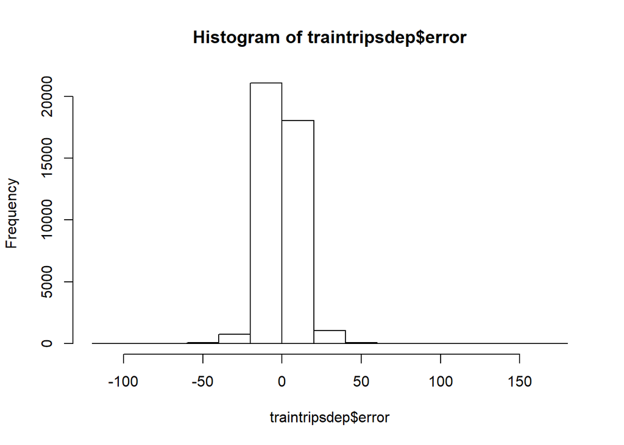

```r
# Check residual plots
hist(traintripsdep$error)
```

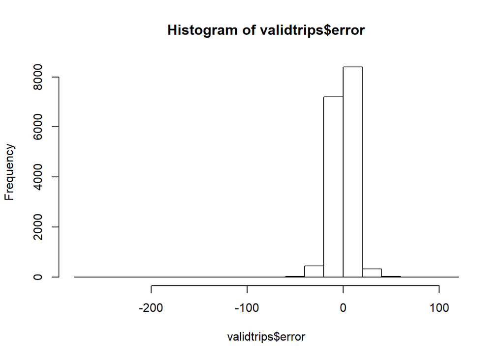

```r
hist(validtrips$error)
```

In both cases the histogram is centered at zero. Espicially with Test data. This is a good test. Follows nornal distribution which is a good measure of model performance.

#### Corelation

```r
# Correlation
a<-cor(traintripsdep$DepDelay,
       traintripsdep$pred.DepDelay )
b<-cor(validtrips$DepDelay,
       validtrips$predict.DepDelay )
a
```

```
## [1] 0.9743257
```

```r
b
```

```
## [1] 0.974039
```

```r
a*a
```

```
## [1] 0.9493105
```

```r
b*b
```

```
## [1] 0.948752
```

#### Corelation between actul and predicted is very high satisfying the accuracy of the model.

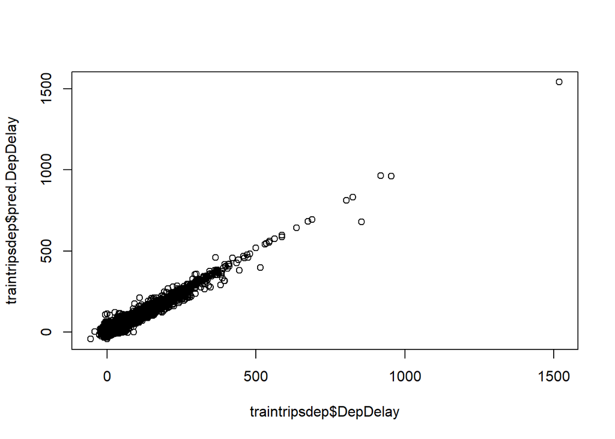

```r
plot(traintripsdep$DepDelay,
     traintripsdep$pred.DepDelay )
```

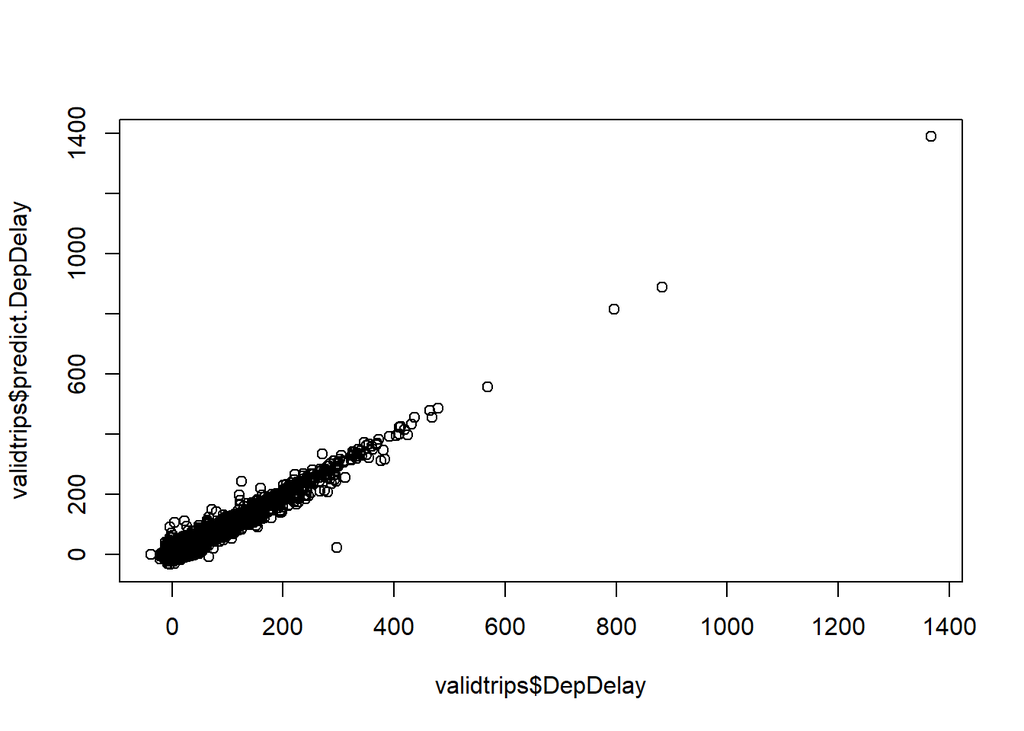

```r
plot(validtrips$DepDelay,
     validtrips$predict.DepDelay )
```

If we look at the Actual vs Predicted it almost follows stright line over diaognal.

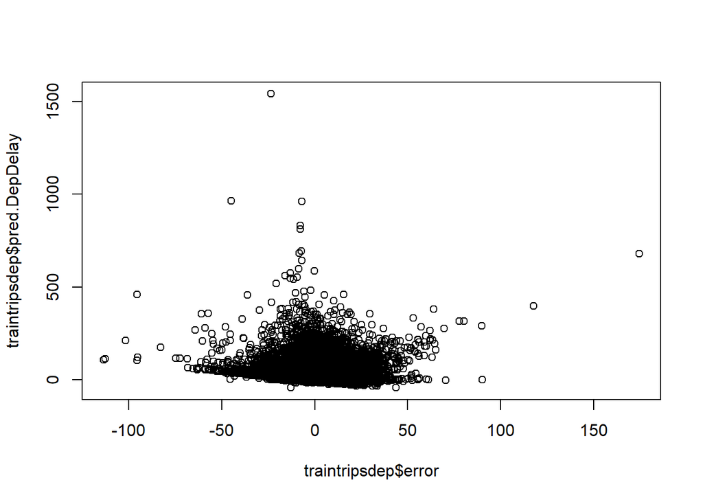

```r
plot(traintripsdep$error,
     traintripsdep$pred.DepDelay )
```

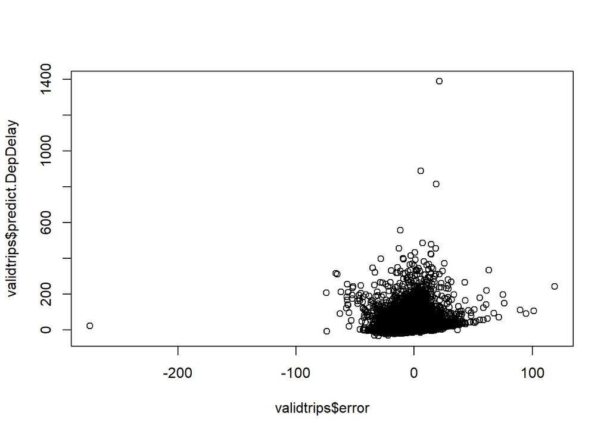

```r
plot(validtrips$error,
     validtrips$predict.DepDelay )
```

Follows normal distributuon. Model performance is good and accuracy is good as well.

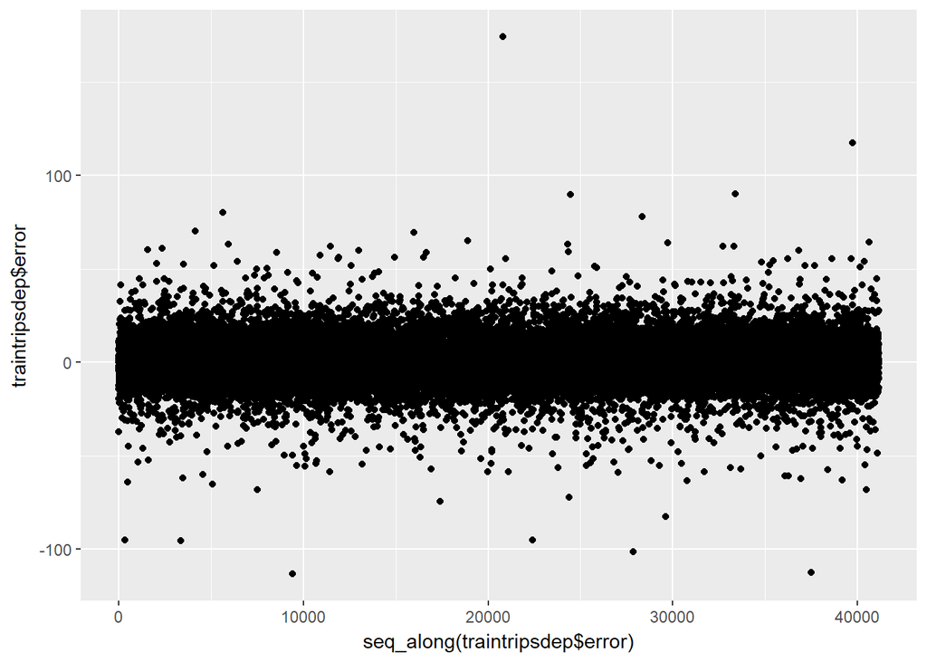

```r
qplot(y=traintripsdep$error)
```

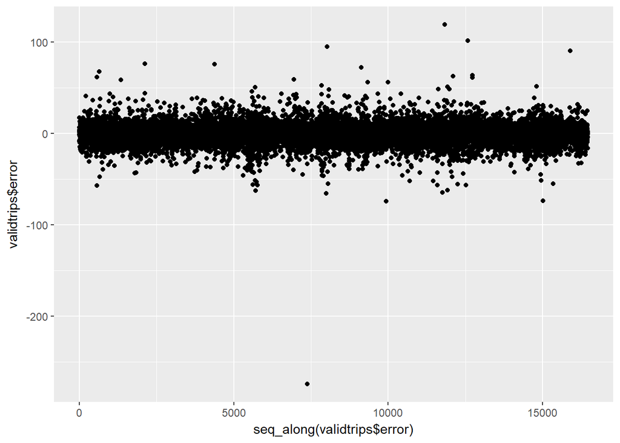

```r
qplot(y=validtrips$error)
```

There are very few outliers which is good as well.

#### regularization: I don’t think it is needed here as co-efficients are not very large. We are not getting any additional benifit.

```r
fitControl <- trainControl(method = "cv", number = 10)  # Cross validation

#ridge.dep.fit1 <- train(DepDelay ~ ., data=traintripsdep, method ='ridge', trControl=fitControl, preProcess= c("scale", "center"))

#lasso.dep.fit2 <- train(DepDelay ~ . , data=traintripsdep, method ='lasso', trControl=fitControl, preProcess= c("scale", "center"))

#summary(ridge.dep.fit1)
#summar(lasso.dep.fit2)
```

###### Let us see if we are able to get any advantage by doing Principal component analysis:

```r
# First remove predictor variable Depdelay and apply

prcomptrainDepdelayvar <- traintripsdep[, grepl("Depdelay" , names(traintrips))]

prcomptraindepdelaydata <- traintripsdep[, !grepl("DepDelay" , names(traintrips))]

prin_comp <- prcomp(prcomptraindepdelaydata )

#compute standard deviation of each principal component
std_dev <- prin_comp$sdev

#compute variance
pr_var <- std_dev^2

#check variance of first 10 components

pr_var[1:10]
```

```
##  [1] 1957.5389835   93.7014509    1.4395084    1.0539409    0.9988223
##  [6]    0.5982956    0.2324916    0.2318921    0.1723994    0.1527356
```

```r
#proportion of variance explained
prop_varex <- pr_var/sum(pr_var)
prop_varex[1:20]
```

```
##  [1] 9.492710e-01 4.543872e-02 6.980620e-04 5.110884e-04 4.843597e-04
##  [6] 2.901320e-04 1.127423e-04 1.124516e-04 8.360176e-05 7.406622e-05
## [11] 7.327698e-05 7.149364e-05 6.975087e-05 6.913606e-05 6.396270e-05
## [16] 6.185293e-05 6.029363e-05 5.658771e-05 5.480135e-05 5.155451e-05
```

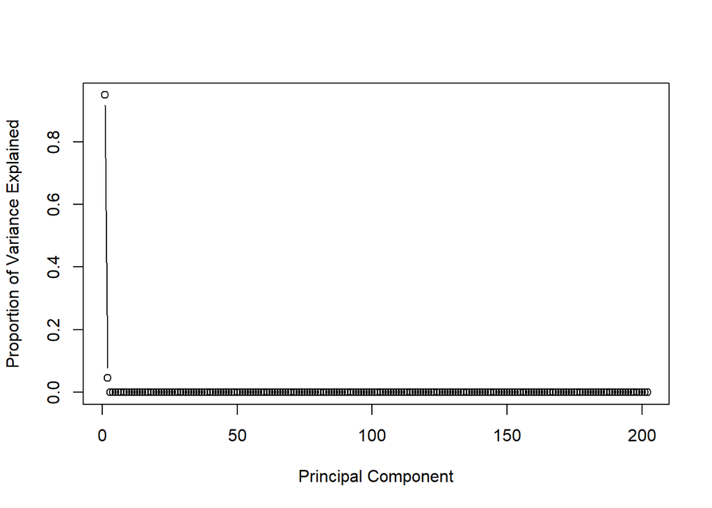

```r
#scree plot
plot(prop_varex, xlab = "Principal Component",
             ylab = "Proportion of Variance Explained",
             type = "b")
```

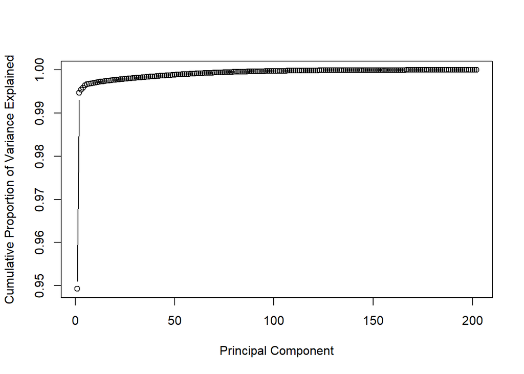

```r
#cumulative scree plot
plot(cumsum(prop_varex), xlab = "Principal Component",
              ylab = "Cumulative Proportion of Variance Explained",
              type = "b")
```